# R Notebook

# Distributions Homework

```r
library(tidyverse)
library(janitor)
```

```r
mobile_phones <- read_csv("data/20190928-items.csv") %>%
  clean_names()
```

## Question 2.

### Find the brand with the highest numbers of phones in the dataset.

```r
mobile_phones %>%
  group_by(brand) %>%
  summarise(count = n()) %>%
  slice_max(count)
```

| brand | count |
| --- | --- |
| Samsung | 397 |

```r
NA
```

## Question 3.

### For your top brand, plot the distribution of phone ratings as a probability density, overlaying a fitted normal distribution. Do you think the normal distribution provides a good model of these ratings?

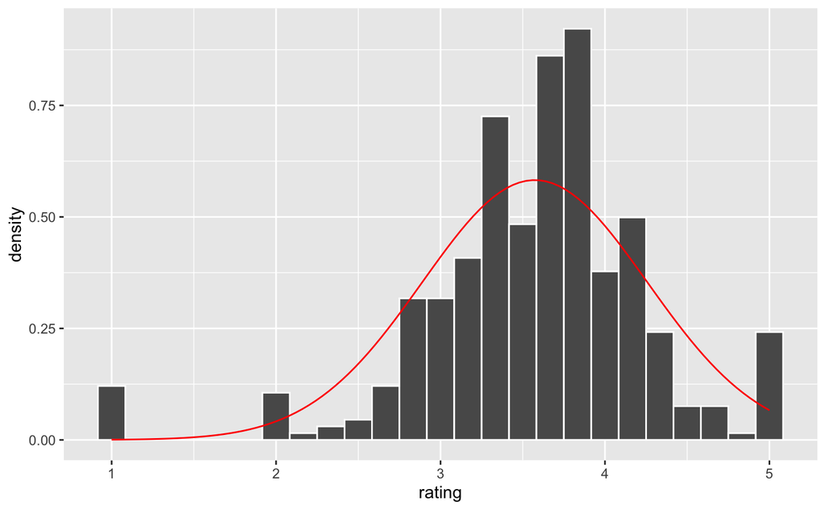

```r
samsung <- mobile_phones %>%
  filter(brand == "Samsung") %>%
  summarise(
    mean = mean(rating),
    sd = sd(rating)
  )



mobile_phones %>%
  filter(brand == "Samsung") %>%
  ggplot(aes(x = rating)) +
  geom_histogram(aes(y = ..density..), col = "white", bins = 25) +
  stat_function(
    fun = dnorm,
    args = list(
      mean = samsung$mean,
      sd = samsung$sd
    ),
    col = "red"
  )
```

> seems somewhat normally distributed the data appears to be left-skewed

## Question 4.

### We can be more quantitative in comparing the distribution of top brand ratings with a normal distribution. You calculated the mean() and sd() of your distribution in an earlier question. Use these values to calculate the proportions of ratings within one-, two- and three standard deviations of the mean. Compare these proportions with those you expect for a normal distribution.

| prop_1sd |
| --- |
| 0.7934509 |

| prop_1sd |
| --- |
| 0.9193955 |

| prop_1sd |
| --- |
| 0.9798489 |

> would expect, if normally distributed, that 99% of the values would be within 3 sd of the mean as there’s about 98% of the data values within 3sd then it seems like the data is left skewed and not normally distributed